# Coursework Report

*N* removed NAs: 2

*N* removed typo: 1

*N* removed <18: 27

*N* total clean: 120

| Group | *N* | *M*<sub>age</sub> | *M*<sub>rating</sub> |
| --- | --- | --- | --- |
| Control | 53 | 20.6 | 5.33 |
| Experim | 67 | 20.6 | 6.82 |

**Main analysis results**

*t*(118) = -11.18, *p* < .001

[interactive chart not shown]

[figure not shown]

[interactive chart not shown]

# Coursework Report

Analysing Data, Spring 2020

# Methods

## Participants

```
## # A tibble: 2 x 5
##   condition        n  perc mean_age sd_age
##   <fct>        <int> <dbl>    <dbl>  <dbl>
## 1 control         53  44.2     20.6   1.77
## 2 experimental    67  55.8     20.6   1.74
```

## Design

Elliot aimed to examine the impact of colours on womens perception of attractiveness in men. He set up 2 conditions. In the control condition, women viewed an image of a man of moderate attractiveness with a white background, in the experimental condition, women veiwed images of the man with a red background. Percieved attractiveness was measured on 3 questions: “how attractive do you think this person is?”, “How pleasent is this person to look at”, and “If I were to meet the person in this picture face to face, i would think he was attractive”. Responses were measured with a 9 point rating scale ranging from 1 (not at all attractive) to 9 (very attractive). Operational hypothesis: Percieved attractiveness of the man in the photo will be effected by whether the background of the photo is red or white. Null hypothesis: Percieved attractiveness will not be affected by the background colour (red or white) of the photo. To test the significance of our results, a t test will be employed to test the significance of the difference in results between conditions.

# Results

Our results show a significant difference between percieved attractiveness ratings in red and white conditions: -11.181, with the red group percieving significantly higher ratings of attractiveness as shown in figure 1.

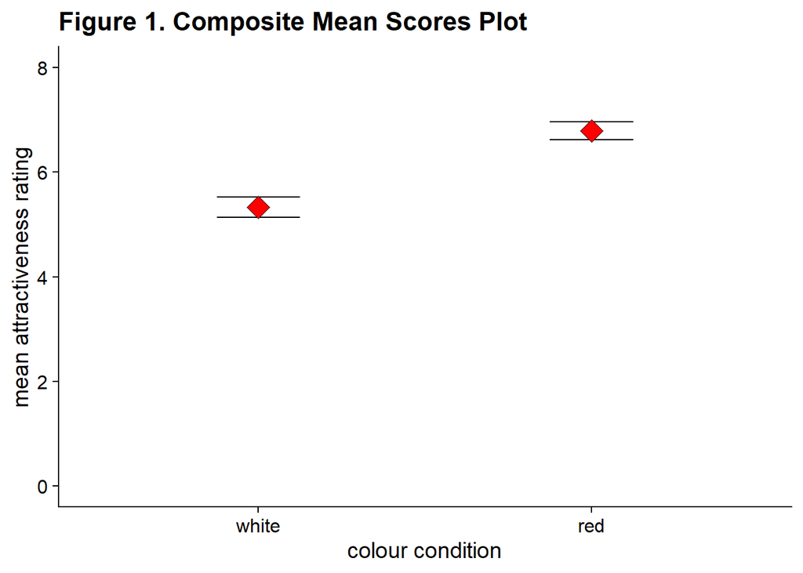

# Discussion

Overall, our results show a moderate increased in rating of perceived attractiveness when images are viewed with a red background instead of a white background. Our t test suggest that the difference between the two conditions is in fact significant.

This study showed high replicability; however, some close replication studies of Elliot’s original found no statistically significant results supporting the red effect. For example, Hesslinger et al, who “found only a significant effect of apparel style” regardless of background colour or clothing colour. They suggested that the theory of red being associated with higher status may have less validity than was initially thought. He found the correlation to perceived status and attractiveness was indeed valid with men dressed in formal, high status clothing being perceived as significantly more attractive than those in casual clothing (Hesslinger et al., 2015).

Elliot’s study’s universal validity has been questioned by evidence from studies such as Young’s study of men’s perception of attractiveness of women in conjunction with the colour red. They found that the red effect was only observed when the face was already perceived as attractive and “red had no influence on perceptions of initially unattractive faces” (Young, 2015). This brings into question the universality of the red effect. To answer this question, initially rated unattractive faces should be used in addition to initially rated “averagely attractive” men’s faces. In addition, men of different racial backgrounds should be tested to investigate the generalisability of the “red effect” across different ethnic backgrounds. In Elliot’s study, only white males were used to rate the effects of red on attractiveness. This not only calls the universality of the red effect into question, but disadvantages other communities from different racial backgrounds by excluding them from this research.

A future study should explore the red effect on a more diverse population. Repeating the methods with male faces that were initially rated as unattractive; and men from different racial backgrounds. A comprehensive comparison of the differences in red effect across these variables should be analysed to fully understand the red effect on females’ perception of male attractiveness.

Ultimately, our replication of Elliot’s study showed support for the “red effect”, however there are many holes in this investigation and further research using a more inclusive representation of men is required for us to fully understand the effect.

# References

Elliot, A. J., Niesta Kayser, D., Greitemeyer, T., Lichtenfeld, S., Gramzow, R. H., Maier, M. A., & Liu, H. (2010). Red, rank, and romance in women viewing men. Journal of Experimental Psychology: General, 139(3), 399–417. https://doi.org/10.1037/a0019689

Hesslinger, V. M., Goldbach, L., & Carbon, C.-C. (2015). Men in red: A reexamination of the red-attractiveness effect. Psychonomic Bulletin & Review, 22(4), 1142–1148. https://doi.org/10.3758/s13423-015-0866-8

Young, S. G. (2015). The effect of red on male perceptions of female attractiveness: Moderation by baseline attractiveness of female faces. European Journal of Social Psychology, 45(2), 146–151. https://doi.org/10.1002/ejsp.2098